# synthetic_control_exploration

# Introduction

One really interesting estimator I never went through at university in any real depth was **Synthetic Control**. This is a great shame because it is a really exciting and honestly quite old estimator now *(and when I was studying!)*. So I thought it might be nice to add a brief *(yet quite in depth)* exploration of this estimator.

The most commonly used package in `R` is the `Synth` package by *Jens Hainmueller and co: Jens Hainmueller aut cre, Alexis Diamond aut, Alberto Abadie aut (2011). “Synth: An R Package for Synthetic Control Methods in Comparative Case Studies.” *Journal of Statistical Software*, 42(13), 1-17. https://www.jstatsoft.org/v42/i13/*.

The package is really simple to use and generally robust for most quasi-experimental panel data applications. So let’s explore what the Synthetic Control (SC) estimator is, a neat application of it and then a bit of a peak under the hood as to what is going on in the `Synth()` function.

```r
library(data.table)
library(tidyverse)
library(Synth)
library(haven)
library(optimx)
library(kernlab)

options(scipen = 999)
```

# Synthetic Control Summary

The basic idea behind the SC is to construct a counterfactual i.e. what would have happened in the absence of of treatment. That is:

$$Causal \ Effect = Actual -
Counterfactual$$

This is the fundamental problem of causal inference, because by definition we cannot observe the counterfactual. The SC tries to estimate this counterfactual position as the weight average of a control group i.e. a set of similar units that did not experience the same treatment as the treated unit. Slightly more formally, this means the above equation becomes:

$$\tau_{1t} = Y_{1t} - WY_{0t}$$
Where both the $Y_{it}$ are the outcome variable of interest for the treated $(1)$ and control $(0)$ units and the $W$ is a vector of weights for each control unit i.e. what percentage of the control units outcome variable should contribute to the counterfactual amount?

This is a really nice approach because of its simplicity and easy interpretability. This approach can be quite easily explained to someone with very little economic background. Where the complexity arises comes is in how to choose the weights in $W$. Specifically, choosing $W$ involves minimising the below optimisation problem:

$$W^* \operatorname{argmin_w} \quad (X_1 - WX_0)'V(X_1 - WX_0))$$

$$s.t \quad W \geq 0, \quad \iota'W = 1$$

Now, before we get into the complexities of solving this problem let’s explore an example to get a better idea of an application of SC.

# Synthetic Control Example

To explore the estimator I will use the famous example from the paper: *Andersson, J.J., 2019. Carbon taxes and CO2 emissions: Sweden as a case study. American Economic Journal: Economic Policy, 11(4), pp.1-30*.

The paper exploits a natural experiment to estimate the effect a carbon tax has on Co2 emissions. In 1990, Sweden was the first country in the world to implement a carbon tax. Because they were the first to implement a carbon tax, Sweden’s emissions can be compared against other “similar” countries emissions to estimate the effect the carbon tax had on emissions. If you have some econometrics background, you might be thinking of applying a difference-in-differences estimator in a scenario like this and you wouldn’t be the first to think that. Unfortunately, the dreaded parallel trends assumption for DiD has raised it’s head again. Investigating the trends visually shows that a DiD estimator is potentially biased *(even if just slightly)*.

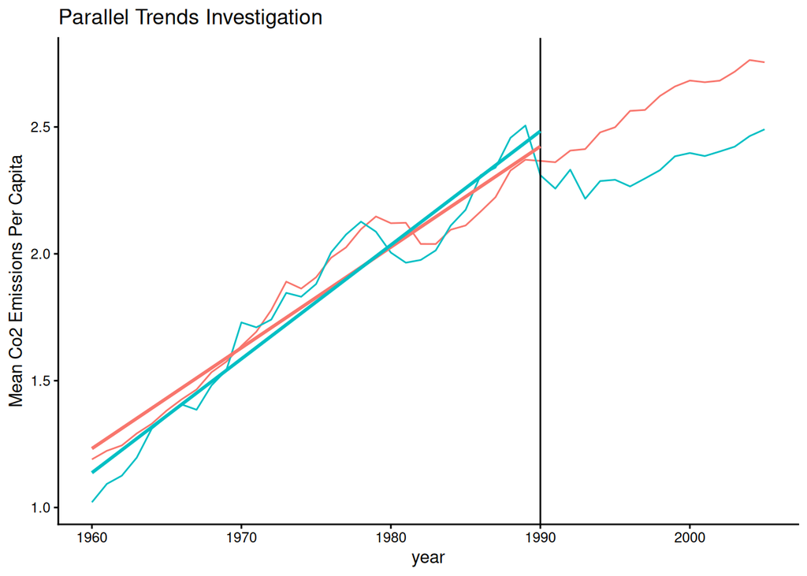

```r
co2 <- setDT(read_dta("/home/michael/Projects/essays/swedish_cp_replication/carbontax_fullsample_data.dta"))

#select countries and filter for years
co2_clean <- co2[country %in% c("Sweden",
                  "Australia",
                  "Belgium",
                  "Canada",
                  "Denmark",
                  "France",
                  "Greece",
                  "Iceland",
                  "Japan",
                  "New Zealand",
                  "Poland",
                  "Portugal",
                  "Spain",
                  "Switzerland",
                  "United States") &
                   year > 1959 &
                   year < 2006]

# fix id
co2_clean[, Countryno := .GRP, by = .(country)]

# clean up environment
rm(co2)

## parallel trends graph
co2_clean %>%
  mutate(treatment = fifelse(Countryno == 13, TRUE, FALSE)) %>%
  group_by(year, treatment) %>%
  summarise(mean_emissions = mean(CO2_transport_capita)) %>%
  ggplot(aes(x = year, y = mean_emissions, color = treatment))+
  geom_line()+
  theme_classic()+
  theme(legend.position = "blank")+
  labs(title = "Parallel Trends Investigation",
       y = "Mean Co2 Emissions Per Capita",
       x = "year")+
  geom_vline(xintercept = as.double(1990), color = "black", type = "--")+
  geom_smooth(method = "lm",
              data = co2_clean %>% filter((year <= 1990)) %>%
                mutate(treatment = fifelse(Countryno == 13, TRUE, FALSE)) %>%
                group_by(year, treatment) %>%
                summarise(mean_emissions = mean(CO2_transport_capita)),
              se = FALSE)
```

This is where the “synthetic control” comes in because it can relax the parallel trends assumption. Because the SC estimator creates weights that take just the “best” parts of all the control units to compare against the treated units outcome variable, the parallel trends assumption is not necessary *(dependent on the pre-intervention fit)*.

So basically, this study utilised this natural experiment of Sweden being the only country to implement a carbon tax to construct a “synthetic version” of Sweden, that never implemented a carbon tax. This allows a comparison of emissions between “synthetic” Sweden that never implemented a carbon tax, and “actual” Sweden that did implement a carbon tax in 1990. If the fit is good, well then in it can be argued that the differences between “actual” and “synthetic” Sweden should be entirely because of the carbon tax, and not some other unobserved factor. In short it would be a causal effect.

This is why SC has become such a popular estimator such that it has been labelled by Susan Athey & Guido W. Imbens as *“the most important innovation in the policy evaluation literature in the last few years”*, https://www.aeaweb.org/articles?id=10.1257/jep.31.2.3.

So enough blabbering about the estimator, let’s take a look at its application using `Synth`. The first thing to create is the data output by using the `dataprep()` function *(we will go into a bit more detail behind what this function is doing later)* as such:

```r
D <- dataprep(foo = co2_clean,
              predictors = c("GDP_per_capita",
                             "gas_cons_capita",
                             "vehicles_capita",
                             "urban_pop"),
              predictors.op = "mean",
              time.predictors.prior = 1980:1989,
              special.predictors = list(
                  list("CO2_transport_capita" , 1989 , "mean"),
                  list("CO2_transport_capita" , 1980 , "mean"),
                  list("CO2_transport_capita" , 1970 , "mean")
              ),
              dependent = "CO2_transport_capita",
              unit.variable = "Countryno",
              unit.names.variable = "country",
              time.variable = "year",
              treatment.identifier = 13,
              controls.identifier = c(1:12,14:15),
              time.optimize.ssr = 1960:1989,
              time.plot = 1960:2005)
```

This function spits out the necessary transformed data to be feed into the `Synth()` function that chooses the weights $W$:

```r
synth_out <- synth(data.prep.obj = D,  verbose = TRUE)
```

```
##
## X1, X0, Z1, Z0 all come directly from dataprep object.
##
##
## ****************
##  searching for synthetic control unit
##
##                    p1         p2         p3        p4       p5        p6
## Nelder-Mead 0.2396621 0.01064359 0.08570843 0.2328969 0.200639 0.3108582
## BFGS        0.1310891 0.13347015 0.02427929 0.1505626 0.151448 0.2918196
##                     p7       value fevals gevals niter convcode kkt1 kkt2 xtime
## Nelder-Mead 0.01469280 0.001222443    501     NA    NA        1   NA   NA 1.038
## BFGS        0.04775456 0.002635084     65     24    NA        0   NA   NA 0.857
##                        p1         p2         p3         p4        p5        p6
## Nelder-Mead -0.0036113994 0.03488777 0.46623718 0.03782121 0.3847244 1.0512324
## BFGS        -0.0002584981 0.05411972 0.08591116 0.11155411 0.1401260 0.6665846
##                     p7       value fevals gevals niter convcode kkt1 kkt2 xtime
## Nelder-Mead 0.08441074 0.001258403    501     NA    NA        1   NA   NA 1.051
## BFGS        0.18688888 0.001625410    113     31    NA        0   NA   NA 1.146
##
##  Equal weight loss is: 0.001222443
##
##  Regression Loss is: 0.001258403
##
## ****************
## ****************
## ****************
##
## MSPE (LOSS V): 0.001222443
##
## solution.v:
##  0.2188493 0.009719276 0.07826532 0.2126716 0.1832151 0.2838626 0.01341685
##
## solution.w:
##  0.0007695733 0.1954709 0.0000561912 0.3842992 0.0003365576 0.09042864 0.001226448 0.0003818197 0.1765464 0.0006891624 0.0003987502 0.0004105377 0.06109071 0.08789508
```

Now that we have $W$ (`synth_out$solution.w` in the output) we can calculate the effects as such:

```r
# simple effects calcs
effects <- D$Y1plot - (D$Y0plot %*% synth_out$solution.w)
print(paste0("The total post intervention difference in Co2 emissions is: ",sum(effects[32:length(effects)])))
```

```
## [1] "The total post intervention difference in Co2 emissions is: -4.49270071384319"
```

```r
print(paste0("The mean post intervention difference in Co2 emissions is: ",mean(effects[32:length(effects)])))
```

```
## [1] "The mean post intervention difference in Co2 emissions is: -0.299513380922879"
```

```r
# percentage changes
effects_prct <- (D$Y1plot - (D$Y0plot %*% synth_out$solution.w))/co2_clean[year == 1990 & Countryno == 13, CO2_transport_capita]

print(paste0("The total percentage change in post intervention difference in Co2 emissions is: ",sum(effects_prct[32:length(effects)])))
```

```
## [1] "The total percentage change in post intervention difference in Co2 emissions is: -1.94498149287638"
```

```r
print(paste0("The mean percentage change in post intervention difference in Co2 emissions is: ",mean(effects_prct[32:length(effects)])))
```

```
## [1] "The mean percentage change in post intervention difference in Co2 emissions is: -0.129665432858426"
```

```r
rm(effects_prct)
```

You can also use the `synth.tab()` function to return the estimates for $W$, the averages of the synthetic Sweden’s predictors in $X$ and the matrix $V$ *(more to come on $V$ later)*:

```r
# tables - creates some nice objects for reporting
synth_tables <- synth.tab(dataprep.res = D, synth.res = synth_out)

## table for weights w
kableExtra::kable(synth_tables$tab.w)
```

|  | w.weights | unit.names | unit.numbers |
| --- | --- | --- | --- |
| 1 | 0.001 | Australia | 1 |
| 2 | 0.195 | Belgium | 2 |
| 3 | 0.000 | Canada | 3 |
| 4 | 0.384 | Denmark | 4 |
| 5 | 0.000 | France | 5 |
| 6 | 0.090 | Greece | 6 |
| 7 | 0.001 | Iceland | 7 |
| 8 | 0.000 | Japan | 8 |
| 9 | 0.177 | New Zealand | 9 |
| 10 | 0.001 | Poland | 10 |
| 11 | 0.000 | Portugal | 11 |
| 12 | 0.000 | Spain | 12 |
| 14 | 0.061 | Switzerland | 14 |
| 15 | 0.088 | United States | 15 |

```r
# predictors
kableExtra::kable(synth_tables$tab.pred)
```

|  | Treated | Synthetic | Sample Mean |
| --- | --- | --- | --- |
| GDP_per_capita | 20121.479 | 20121.207 | 18706.663 |
| gas_cons_capita | 456.178 | 406.220 | 425.510 |
| vehicles_capita | 405.562 | 406.773 | 402.368 |
| urban_pop | 83.099 | 83.082 | 75.238 |
| special.CO2_transport_capita.1989 | 2.506 | 2.478 | 2.371 |
| special.CO2_transport_capita.1980 | 2.005 | 2.033 | 2.121 |
| special.CO2_transport_capita.1970 | 1.729 | 1.672 | 1.637 |

```r
# matric V
kableExtra::kable(synth_tables$tab.v)
```

|  | v.weights |
| --- | --- |
| GDP_per_capita | 0.219 |
| gas_cons_capita | 0.01 |
| vehicles_capita | 0.078 |
| urban_pop | 0.213 |
| special.CO2_transport_capita.1989 | 0.183 |
| special.CO2_transport_capita.1980 | 0.284 |
| special.CO2_transport_capita.1970 | 0.013 |

One of the really attractive properties of the SC estimator is it’s really easy to visualise the counterfactual against the actual, as well as the gap between the two:

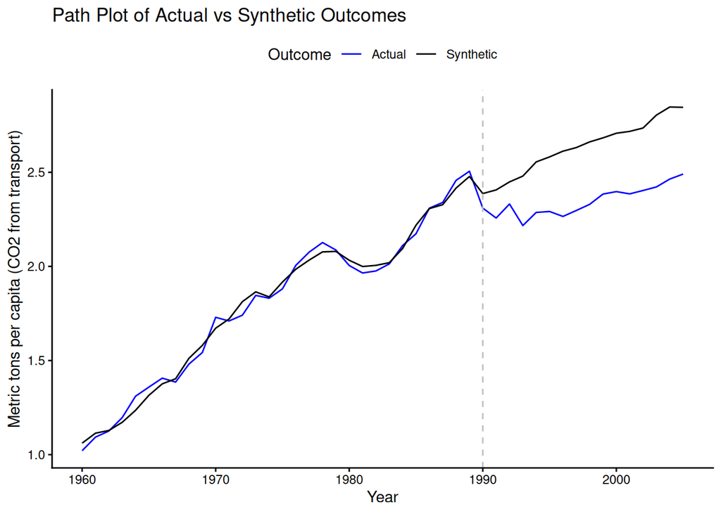

```r
# plots from ggplot
## plot data
data_plot <- data.table(year = 1960:2005,
                        co2_actual = D$Y1plot,
                        co2_synth = D$Y0plot %*% synth_out$solution.w,
                        effects = D$Y1plot - (D$Y0plot %*% synth_out$solution.w))

names(data_plot) <-  c("year", "co2_actual", "co2_synth", "effects")

## path plot
data_plot %>%
  ggplot(aes(x = year)) +
  geom_line(aes(y = co2_actual, color = "Actual")) +
  geom_line(aes(y = co2_synth, color = "Synthetic")) +
  labs(title = "Path Plot of Actual vs Synthetic Outcomes",
       x = "Year",
       y = "Metric tons per capita (CO2 from transport)") +
  scale_color_manual(name = "Outcome", values = c("Actual" = "blue", "Synthetic" = "black")) +
  theme_classic()+
  theme(legend.position = "top")+
  geom_vline(xintercept = 1990, linetype = 'dashed', color = "grey")
```

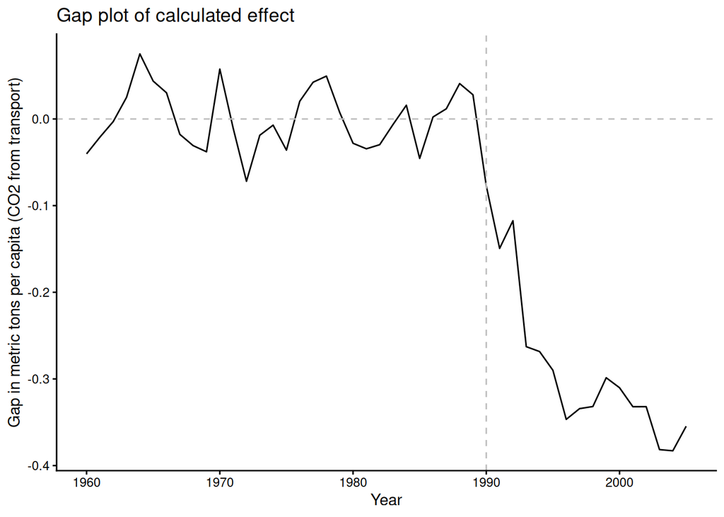

```r
## gap plot
data_plot %>%
  ggplot(aes(x = year, color)) +
  geom_line(aes(y = effects), color = "black") +
  labs(title = "Gap plot of calculated effect",
       x = "Year",
       y = "Gap in metric tons per capita (CO2 from transport)") +
  theme_classic()+
  theme(legend.position = "top")+
  geom_hline(yintercept = 0, linetype = 'dashed', color = "grey")+
  geom_vline(xintercept = 1990, linetype = 'dashed', color = "grey")
```

AS you can see, the pre-intervention fit is quite similar such that they almost certainly have the same trends. This is positive evidence that the effect calculate can be attributed to the carbon tax and not some other unobserved factor. However, in saying that another really simple test to determine the significance of the result is the “placebo” test.

This involves running each of the control units through the SC estimator as if it was a treated unit. Because they never received the treatment *(a carbon tax)*, we would expect their results to be close to zero *(statistically insignificant)*. We can implement a placebo test as such:

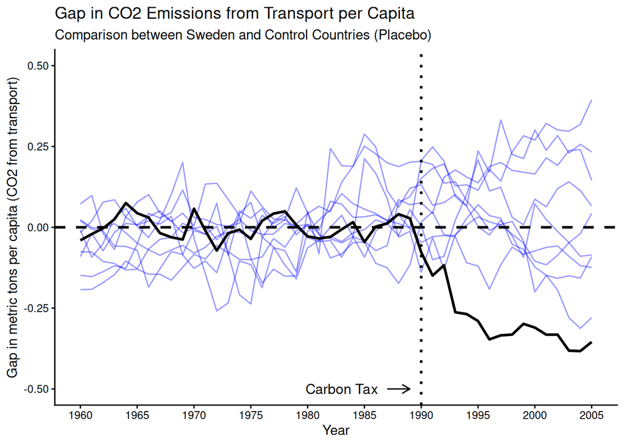

```r
# placebo test for loop
## initialise data
store <- matrix(NA,length(1960:2005),15)
colnames(store) <- unique(co2_clean$country)

# run loop
for(iter in 1:15){
 dataprep.out <-
              dataprep(foo = co2_clean,
                       predictors = c("GDP_per_capita" ,
                                      "gas_cons_capita" ,
                                      "vehicles_capita" ,
                                      "urban_pop") ,
                       predictors.op = "mean" ,
                       time.predictors.prior = 1980:1989 ,
                       special.predictors = list(
                         list("CO2_transport_capita" , 1989 , "mean"),
                         list("CO2_transport_capita" , 1980 , "mean") ,
                         list("CO2_transport_capita" , 1970 , "mean")
                         ),
                       dependent = "CO2_transport_capita",
                       unit.variable = "Countryno",
                       unit.names.variable = "country",
                       time.variable = "year",
                       treatment.identifier = iter, # note here the loop changes the treated unit for each loop
                       controls.identifier = c(1:15)[-iter],
                       time.optimize.ssr = 1960:1989,
                       time.plot = 1960:2005
                       )

# run synth
synth.out <- synth(data.prep.obj = dataprep.out, method = 'L-BFGS-B')

# store gaps
store[,iter] <- dataprep.out$Y1plot - (dataprep.out$Y0plot %*% synth.out$solution.w)
} # end of placebo loop

data <- store
rownames(data) <- 1960:2005

# Set bounds
gap.start     <- 1
gap.end       <- nrow(data)
years         <- 1960:2005
gap.end.pre  <- which(rownames(data)=="1989")

#  MSPE Pre-Treatment
mse  <- apply(data[ gap.start:gap.end.pre,]^2,2,mean)
sweden.mse <- as.numeric(mse[13])
# Exclude MSPE > 20 (really bad fits)
data <- data[,mse<20*sweden.mse]
Cex.set <- 1

data_long <- data.table::melt(as.data.table(data, keep.rownames = TRUE),
                              id.vars = "rn",
                              variable.name = "Country",
                              value.name = "Gap")

data_long$Year <- as.integer(data_long$rn)

data_long %>%
  ggplot(aes(x = Year, y = Gap, group = Country)) +
  geom_line(data = subset(data_long, Country != "Sweden"),
            aes(color = "Control Countries"), color = "blue", alpha = 0.4) +
  geom_line(data = subset(data_long, Country == "Sweden"),
            aes(color = "Sweden"), color = "black", linewidth = 1) +
  geom_vline(xintercept = 1990, linetype = "dotted", linewidth = 1) +
  geom_hline(yintercept = 0, linetype = "dashed", linewidth = 1) +
  scale_x_continuous(breaks = seq(1960, 2005, 5)) +
  scale_y_continuous(limits = c(-0.5, 0.5)) +
  labs(x = "Year", y = "Gap in metric tons per capita (CO2 from transport)",
       title = "Gap in CO2 Emissions from Transport per Capita",
       subtitle = "Comparison between Sweden and Control Countries (Placebo)") +
  theme_classic() +
  theme(legend.position = "bottomleft") +
  annotate("text", x = 1983, y = -0.5, label = "Carbon Tax", size = 4) +
  annotate("segment", x = 1987, xend = 1989, y = -0.5, yend = -0.5, color = "black", arrow = arrow(length = unit(0.1, "inches"))) +
  guides(color = guide_legend(override.aes = list(linetype = c(1, 1), color = c("black", "gray"), size = c(1, 0.5))))
```

Note that those units with a mean square error 20 times that of Sweden’s mean square error are removed because they have a really poor fit i.e. the model struggles to find a good set of $W$.

There are other tests such as the ratios of MSPE and “in-time placebo” test, but I think this suffices for this example.

Another property of SC is the sparsity of weights. In the plot below we can see that the choosen $W$ assigns basically all of the weights to only 6 of the 14 possible control units. This is a property of the “convexity” constraint required when estimating $W$. There is some reasearch that suggests this is a potential problem if the number of control units exceeds the number of predictors, and other estimators have been created to try resolve this *(synthetic difference-in-differences)*. But for now, it’s just an interesting property for us to note.

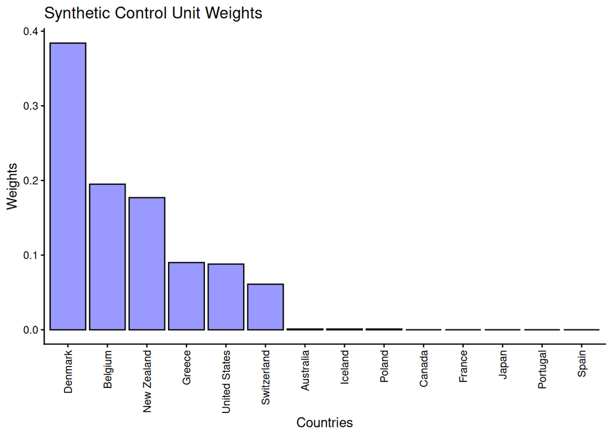

```r
# Create a data frame for the weights
data.frame(country = synth_tables$tab.w$unit.names,
           Weight = synth_tables$tab.w$w.weights) %>%
  ggplot(aes(x = reorder(country, -Weight), y = Weight)) +
  geom_bar(stat = "identity", fill = "blue", color = "black", alpha = 0.4) +
  labs(title = "Synthetic Control Unit Weights",
       x = "Countries",
       y = "Weights") +
  theme_classic()+
  theme(axis.text.x = element_text(angle = 90, vjust = 0.5, hjust=1))
```

# A deep dive into Synthetic Control

Now that we’ve seen an application using `Synth` and the sort of results you can produce with it, lets dig into the code a bit deeper to get a better idea at what is going on underneath the hood!

## data transformations

Now, we saw that complex looking `dataprep()` function that returns transformed data that can feed directly into the `Synth()` function itself.

This probably seems like a blackbox that just handily outputs the data we need to calculate the weights. But, really the transformations aren’t really that complex.

So, I thought it would be helpful to illustrate what this function is actually doing.

Firstly, let’s look some of the inputs in the `dataprep` object and what they do.

- `foo` is the data.frame or table your data is stored in. In the above example this is the `co2_data`.
- `predictors` are the predictors that form *(part of the $X$ matrices)* used in the optimisation problem.
- `predictors.op` is the operation applied to the treated $X$ matrices *(i.e. mean or median etc - mean is usually sufficient)*.
- `special.predictors` are the *(special)* predictors that form *(part of the $X$ matrices)* used in the optimisation problem. In our example these are a list of a list of the lags for the output variable we want to include.
- `unit.variable` is the column name identifying the unit dimension i.e. countries numbers or “Countryno” in our case.
- `unit.names.variable` is the unit variables actual names i.e. the countries actual names and not just an index number in `unit.variable`.
- `time.variable` is the column that identifies the time dimension in our panel i.e. the year.

In practice you will have to set most of the above examples plus a few more as outlined in the `dataprep()` function above. However, for our purposes we only need a few of the key arguments to explore the transformations. Noteably we need the:

- `dependent` is the dependent variable of interest i.e. co2 emissions per capita.
- `treatment.identifier` is an index identifying which unit is the treated in the `unit.variable` column.
- `controls.identifier` are indexes identifying which units are the controls in the `unit.variable` column.
- `time.predictors.prior` is a list identifying the pre-intervention periods over which the special predictors should be averaged.
- `time.optimize.ssr` is a list identifying the pre-intervention periods over which the loss function is minimised.
- `time.plot` is a list identifying all time periods. If nothing is provided, this will default to `time.optimize.ssr`. But in our case we will set this to the whole period.

```r
# this is the variable of interest
dependent <-  "CO2_transport_capita"

# this is a arguement that identifies which of the `unit.variable` is the treated unit. For out case it is unit 13
treatment.identifier  <- 13

# this is a list identifying the remaining units that are controls (only one unit can be treated in this example)
controls.identifier <-  c(1:12,14:15)

# a list identifying the pretreatment periods over which the special predictors should be averaged
time.predictors.prior <-  1980:1989

# a list identifying the pretreatment periods over which the loss function is minimised
time.optimize.ssr <-  1960:1989

# this sets up the time we want to plot the data. Not important for our case tbh.
# if nothing is provided, this will default to `time.optimize.ssr`. But in our case we will set this to the whole period.
time.plot <-  1960:2005
```

Now that we’ve set up all the key arguments, let’s explore the actual transformations.

Firstly let’s look at the $X_i$ matrices. These matrices basically contain variables (`predictors`) that help fit the weights we want to estimate. $X_1$ is the mean of all the treated units predictors (plus some lags in our example - contained in the `special.predictors` argument). $X_0$ is the same but for the control units.

Note that to make sure the dimensions line up, we have to transpose these tables such that the columns relate to the units.

```r
# X0
X0 <- t(co2_clean[Countryno != treatment.identifier & year %in% time.predictors.prior,
          .(GDP_per_capita = mean(GDP_per_capita, na.rm = TRUE),
            gas_cons_capita = mean(gas_cons_capita, na.rm = TRUE),
            vehicles_capita = mean(vehicles_capita, na.rm = TRUE),
            urban_pop = mean(urban_pop, na.rm = TRUE),
            special.CO2_transport_capita.1989 = CO2_transport_capita[year == 1989],
            special.CO2_transport_capita.1980 = CO2_transport_capita[year == 1980]),
          by = .(Countryno)] %>% select(-Countryno))


# have to add 1970 later because of time filter above
X0 <- rbind(X0, special.CO2_transport_capita.1970 = co2_clean[Countryno != treatment.identifier,CO2_transport_capita[year == 1970]])
# add columnn names
colnames(X0) <- controls.identifier

# printing just five columns
kableExtra::kable(X0[,1:5])
```

|  | 1 | 2 | 3 | 4 | 5 |
| --- | --- | --- | --- | --- | --- |
| GDP_per_capita | 21514.898885 | 19241.689826 | 23940.543486 | 20990.265085 | 19727.154693 |
| gas_cons_capita | 734.108984 | 277.109925 | 978.407078 | 288.815347 | 318.585016 |
| vehicles_capita | 536.806625 | 371.981683 | 561.759125 | 343.236859 | 436.133378 |
| urban_pop | 85.526000 | 95.868900 | 76.196100 | 84.286200 | 73.613400 |
| special.CO2_transport_capita.1989 | 3.604054 | 2.042727 | 4.654662 | 2.199667 | 1.871162 |
| special.CO2_transport_capita.1980 | 3.339913 | 1.607629 | 5.200667 | 1.733350 | 1.595845 |
| special.CO2_transport_capita.1970 | 2.569761 | 1.170311 | 3.779310 | 1.462843 | 1.062707 |

```r
# X1
X1 <- t(co2_clean[Countryno == treatment.identifier & year %in% time.predictors.prior,
          .(GDP_per_capita = mean(GDP_per_capita, na.rm = TRUE),
            gas_cons_capita = mean(gas_cons_capita, na.rm = TRUE),
            vehicles_capita = mean(vehicles_capita, na.rm = TRUE),
            urban_pop = mean(urban_pop, na.rm = TRUE),
            special.CO2_transport_capita.1989 = CO2_transport_capita[year == 1989],
            special.CO2_transport_capita.1980 = CO2_transport_capita[year == 1980]),
          by = .(Countryno)] %>% select(-Countryno))


# have to add 1970 later because of time filter above
X1 <- rbind(X1, special.CO2_transport_capita.1970 = co2_clean[Countryno == treatment.identifier,CO2_transport_capita[year == 1970]])
# add columnn names
colnames(X1) <- treatment.identifier

kableExtra::kable(X1)
```

|  | 13 |
| --- | --- |
| GDP_per_capita | 20121.479093 |
| gas_cons_capita | 456.178040 |
| vehicles_capita | 405.561575 |
| urban_pop | 83.098700 |
| special.CO2_transport_capita.1989 | 2.505603 |
| special.CO2_transport_capita.1980 | 2.004685 |
| special.CO2_transport_capita.1970 | 1.729497 |

Secondly, the $Z_i$ matrices contain the outcome variable over the period we want to optimise (pre-intervention period denoted by the `time.optimize.ssr` argument). The transformations for this again are quite simple such that we basically just cast the unit row to the columns such that we get a matrix with $T$ rows and $n$ columns. All the elements in this matrix are for the outcome variable (the `dependent` argument). Obviously, we complete these transformations separately for the treated and control units.

```r
# Z0
Z0 <- dcast(co2_clean[Countryno != treatment.identifier & year %in% time.optimize.ssr,
                      .(Countryno, year, CO2_transport_capita)],
            year ~ Countryno, value.var = dependent) %>% select(-year) %>% as.matrix()

rownames(Z0) <- time.optimize.ssr

# print just five columns and five rows
kableExtra::kable(Z0[1:5, 1:5])
```

|  | 1 | 2 | 3 | 4 | 5 |
| --- | --- | --- | --- | --- | --- |
| 1960 | 2.092157 | 0.7658282 | 2.799708 | 0.7205865 | 0.7631702 |
| 1961 | 2.047124 | 0.7905097 | 2.763943 | 0.7784570 | 0.7876295 |
| 1962 | 2.094582 | 0.8047218 | 2.840335 | 0.8089976 | 0.7832856 |
| 1963 | 2.226484 | 0.8073397 | 2.938726 | 0.8773647 | 0.8347534 |
| 1964 | 2.290678 | 0.8338564 | 3.056662 | 0.9445006 | 0.8616085 |

```r
# Z1
Z1 <- dcast(co2_clean[Countryno == treatment.identifier & year %in% time.optimize.ssr,
                      .(Countryno, year, CO2_transport_capita)],
            year ~ Countryno, value.var = dependent) %>% select(-year) %>% as.matrix()

rownames(Z1) <- time.optimize.ssr

# just five rows
kableExtra::kable(Z1[1:5])
```

| x |
| --- |
| 1.020755 |
| 1.093085 |
| 1.125425 |
| 1.196687 |
| 1.310473 |

Another helpful object the `dataprep()` function returns is the `Y1plot` and `Y0plot` dataframes. The transformations for these are exactly the same as the $Z_i$ matrices, however we now include all the time periods (pre- and post-intervention - set by the `time.plot` argument, but we don’t need to make any filters because the argument is set to all the years). This becomes helpful when constructing the counterfactual, because `synth_cf = w.solution %*% Y0plot` that can be easily compared to `Y1plot` to estimate the effect i.e. `effect = Y1plot - synth_cf`.

```r
# plots
# Y0plot
Y0plot <- dcast(co2_clean[Countryno != treatment.identifier,
                      .(Countryno, year, CO2_transport_capita)],
            year ~ Countryno, value.var = dependent) %>% select(-year) %>% as.matrix()

rownames(Y0plot) <- time.plot

# kableExtra::kable(Y0plot)

# Y1plot
Y1plot <- dcast(co2_clean[Countryno == treatment.identifier,
                      .(Countryno, year, CO2_transport_capita)],
            year ~ Countryno, value.var = dependent) %>% select(-year) %>% as.matrix()

rownames(Y1plot) <- time.plot

# names and numbers
names.and.numbers <- data.frame(c(co2_clean[Countryno ==treatment.identifier, unique(country)],co2_clean[Countryno !=treatment.identifier, unique(country)]),
                                c(co2_clean[Countryno ==treatment.identifier, unique(Countryno)],co2_clean[Countryno !=treatment.identifier, unique(Countryno)]))
names(names.and.numbers) <- c("unit.names", "unit.numbers")

# printing names and numbers
kableExtra::kable(names.and.numbers)
```

| unit.names | unit.numbers |
| --- | --- |
| Sweden | 13 |
| Australia | 1 |
| Belgium | 2 |
| Canada | 3 |
| Denmark | 4 |
| France | 5 |
| Greece | 6 |
| Iceland | 7 |
| Japan | 8 |
| New Zealand | 9 |
| Poland | 10 |
| Portugal | 11 |
| Spain | 12 |
| Switzerland | 14 |
| United States | 15 |

You will see that last object we return is the dataframe `names.and.numbers`. It contains all the treated and control unit numbers and names to create nice tables later.

There are a lot more checks and balances in the actual source code to make sure you can’t *(or don’t)* mess anything up when you set up the `dataprep` object. But for our purposes of exploration, the above transformations show what the underlying source code achieves. So it will suffice for now :)

## Loss Function

Okay great, we’ve now for all the data structures we need to estimate $W$ *(and $V$)*. We have $Z_1$, $Z_0$, $X_1$ and $X_0$. We also have the matrices to calculate the counterfactual. But before, we do that we have to solve the optimisation problem! From the brief introduction above it means solving this optimistion problem for $W$:

$$W^* \operatorname{argmin_w} \quad (X_1 - WX_0)'V(X_1 - WX_0)) \\$$

$$s.t \quad W \geq 0, \quad \iota'W = 1$$

Now this might seem like quite a challenging optimisation problem, and in a way it is. But, this problem can be reformulated into a typically quadratic optimisation problem. Let’s explore how by first expanding and then rearranging the above loss function:

$$(X_1 - WX_0)'V(X_1 - WX_0)) = X_1'VX_1 - X_1'VWX_0 -
W'X_0'VX_1 + W'X_0'VWX_0$$

$$= W'(X_0'VX_0)W - 2(X_0'VX_1)W' + X_1'VX_1$$

Now this probably looks just as confusing, however the above can be fit quite nicely into the standard quadratic optimisation problem:

$$\frac{1}{2} W'HW + c'W$$

We can match the above notation to this general quadratic problem by setting the quadratic term to $H$ as such:

$$W'(X_0'VX_0)W = \frac{1}{2}W'HW \Rightarrow (X_0'VX_0) =
\frac{1}{2}H$$

We can do a similar matching to $c$ as such:

$$c'W = - 2(X_0'VX_1)W' \Rightarrow c = - 2(X_0'VX_1)$$

When we put all this together we can see that:

$$\frac{1}{2} W'HW + c'W = W'(X_0'VX_0)W - 2(X_0'VX_1)$$

Note that the constant term $X_1'VX_1$ will fall off in the optimisation problem once we take the derivative with respect to $W$. So we can basically ignore it.

Now this took me an unreasonably long amount of time to decipher so I might *(still)* have some of that wrong. But, for more on quadratic programming the wiki is a good start: https://en.wikipedia.org/wiki/Quadratic_programming. But the `Synth` package uses the `ipop` function from the `kernlab` package which has a similar functional form to the above to solve for $W$ *(with some nuances)*: https://www.rdocumentation.org/packages/kernlab/versions/0.9-29/topics/ipop.

Now before we can actually solve for $W$, we first need to choose the $V$ to input into the above equation. There are quite a few ways to do this but the `Synth` function uses a fancy data driven method to choose $V$. By minimsing the below function we get an optimised $V^*$ to be used in the optimisation problem for $W$. It’s basically just a nested function that chooses $V$ that minimises the mean square prediction error of the pre-intervention periods we set up earlier i.e. $Z_1$ and $Z_0$. Specifically, it minimises:

$$\operatorname{argmin_V}(Z_1 - Z_0W(V))'(Z_1 - Z_0W(V))$$

Below is a simplified version of the function from the `Synth` package itself *(note the comments I’ve left to explain my interpretation of how they fit together with what is outlined above)*.

```r
## to view the full function used in the package run the code below
# view(Synth::fn.V)

# function to optimise for V
V_MSPE <- function (variables.v = stop("variables.v missing"),
                  X0.scaled = stop("X0.scaled missing"),
                  X1.scaled = stop("X1.scaled missing"),
                  Z0 = stop("Z0 missing"),
                  Z1 = stop("Z1 missing"),
                  margin.ipop = 0.0005,
                  sigf.ipop = 5,
                  bound.ipop = 10#,
                  #quadopt = "ipop"
                  ){

  # this is the definition of the V matrix
  V <- diag(x = as.numeric(abs(variables.v)/sum(abs(variables.v))), nrow = length(variables.v), ncol = length(variables.v))
  H <- t(X0.scaled) %*% V %*% (X0.scaled) # H matrix set to X_0'VX_0 as above (1/2 removed as it's already in the ipop function)
  a <- X1.scaled # This helps define the dimensions for c
  c <- -1 * c(t(a) %*% V %*% (X0.scaled)) # note that this is -1 instead of -2 because the H is multiplied by 1/2 (this exploded my head a bit but it works out once you take the derivatives)
  A <- t(rep(1, length(c)))  # by setting A to the identity vector this sets the condition to ensure W sums to one (r = 0, therefore b + r = 1)
  b <- 1 # sets upper limit on sum of W
  l <- rep(0, length(c)) # sets the lower bound for each element of W as 0
  u <- rep(1, length(c)) # sets the upper bound for each element of W as 1
  r <- 0 # ensures b + r = 1

  # have to solve for W to get the loss for V (we don't use these estimates of W)
  res <- ipop(c = c,
              H = H,
              A = A,
              b = b,
              l = l,
              u = u,
              r = r,
              bound = bound.ipop,
              margin = margin.ipop,
              maxiter = 1000,
              sigf = sigf.ipop)

  solution.w <- as.matrix(primal(res)) # returns solution for W

  loss.v <- as.numeric(t(Z1 - Z0 %*% solution.w) %*% (Z1 -Z0 %*% solution.w)) # this is the squared prediction error
  loss.v <- loss.v/nrow(Z0) # this is the MSPE
  return(invisible(loss.v))
}
```

## Estimation

Okay now that we’ve explore the loss functions, let’s actually use it to estimate the weights!

The first thing the `Synth()` function does is normalise the matrices $X_i$ by the standard deviation:

```r
nvarsV <- dim(X0)[1]
big.dataframe <- cbind(X0, X1)
divisor <- sqrt(apply(big.dataframe, 1, var))

scaled.matrix <- t(t(big.dataframe) %*% (1/(divisor) * diag(rep(dim(big.dataframe)[1], 1)) )) # last bit is the identify matrix such that it becomes the sd matrix once multiplied by sd estimates

# split the variances back out into X_1 and X_0
X0.scaled <- scaled.matrix[, 1:ncol(X0), drop = FALSE]
X1.scaled <- scaled.matrix[, ncol(scaled.matrix)]
```

Now that we’ve scaled the input matrices, we can set up the optimsiation problem for $V$. The package itself is a little bit more complicated when setting the initial values for $V$, but for us we can set the initial paramater guesses for $V$ as equal weights in `SV1`. Then we can put all the variables into the `optimx()` function and return the solution for $V$:

```r
SV1 <- rep(1/nvarsV,nvarsV)

# now we can estimate the parameters
opt_res <- optimx::optimx(par=SV1, # initial guesses
                  fn=V_MSPE, # V MSPE function
                  method=c("Nelder-Mead","BFGS"),
                  X0.scaled = X0.scaled,
                  X1.scaled = X1.scaled,
                  Z0 = Z0,
                  Z1 = Z1
                  )

# the collect.otpimx() is just a helpful little function that returns the parameters of interest for use
# run this code if you want to have a look at it
# view(collect.optimx)

opt_res <- collect.optimx(opt_res,"min")

solution.v  <- abs(opt_res$par)/sum(abs(opt_res$par))
```

Great, we now have the solution for $V^*$, so we can we can now estimate $W(V*)$ using the `ipop` function to solve the loss function:

```r
# below is functionally the same code as the function we explored above, but now we have V
V <- diag(x=as.numeric(solution.v),nrow=nvarsV,ncol=nvarsV) # solution from optimisation problem above acts as our V
H <- t(X0.scaled) %*% V %*% (X0.scaled)
a <- X1.scaled
c <- -1*c(t(a) %*% V %*% (X0.scaled) )
A <- t(rep(1, length(c)))
b <- 1
l <- rep(0, length(c))
u <- rep(1, length(c))
r <- 0

# optimisation problem solving for W
quad_res <- kernlab::ipop(c = c,
            H = H,
            A = A,
            b = b,
            l = l,
            u = u,
            r = r,
            margin =  0.0005, # how close we can get to the constraints
            maxiter = 1000, # max number of iterations
            sigf = 5, # precision
            bound = 10) # clipping bound for variables

solution.w <- as.matrix(primal(quad_res))

# add names to out solutions
rownames(solution.w) <- colnames(X0)
colnames(solution.w) <- "w.weight"
names(solution.v) <- rownames(X0)

# estimate loss function values at solution
loss.w <- t(X1.scaled - X0.scaled %*% solution.w) %*% V %*% (X1.scaled - X0.scaled %*% solution.w)
loss.v <- t(Z1 - Z0 %*% as.matrix(solution.w)) %*% (Z1 - Z0 %*% as.matrix(solution.w)) /nrow(Z0)
```

Great! Now let’s see if these results are the same as the ones we saw when using the `Synth()` function in the example.

```r
# now we have the optimised solutions for W(V)
# table for W
kableExtra::kable(data.frame(round(solution.w,4),
           names.and.numbers[-which(names.and.numbers[,2]==treatment.identifier),]))
```

|  | w.weight | unit.names | unit.numbers |
| --- | --- | --- | --- |
| 1 | 0.0008 | Australia | 1 |
| 2 | 0.1955 | Belgium | 2 |
| 3 | 0.0001 | Canada | 3 |
| 4 | 0.3843 | Denmark | 4 |
| 5 | 0.0003 | France | 5 |
| 6 | 0.0904 | Greece | 6 |
| 7 | 0.0012 | Iceland | 7 |
| 8 | 0.0004 | Japan | 8 |
| 9 | 0.1765 | New Zealand | 9 |
| 10 | 0.0007 | Poland | 10 |
| 11 | 0.0004 | Portugal | 11 |
| 12 | 0.0004 | Spain | 12 |
| 14 | 0.0611 | Switzerland | 14 |
| 15 | 0.0879 | United States | 15 |

```r
# predictor comparisons
tab.pred <- round(cbind(X1,
                        as.matrix(X0)%*%as.matrix(solution.w),
                        apply(as.matrix(X0),1,mean)), 4)

colnames(tab.pred) <- c("Treated", "Synthetic", "Sample Mean")

kableExtra::kable(tab.pred)
```

|  | Treated | Synthetic | Sample Mean |
| --- | --- | --- | --- |
| GDP_per_capita | 20121.4791 | 20121.2065 | 18706.6630 |
| gas_cons_capita | 456.1780 | 406.2203 | 425.5100 |
| vehicles_capita | 405.5616 | 406.7735 | 402.3681 |
| urban_pop | 83.0987 | 83.0821 | 75.2381 |
| special.CO2_transport_capita.1989 | 2.5056 | 2.4777 | 2.3709 |
| special.CO2_transport_capita.1980 | 2.0047 | 2.0327 | 2.1207 |
| special.CO2_transport_capita.1970 | 1.7295 | 1.6719 | 1.6367 |

```r
# table for V matrix (diag)
tab.v <- matrix(round(solution.v, 4), nrow=length(solution.v))
rownames(tab.v) <- rownames(X1)
colnames(tab.v) <- c("v.weights")

kableExtra::kable(tab.v)
```

|  | v.weights |
| --- | --- |
| GDP_per_capita | 0.2188 |
| gas_cons_capita | 0.0097 |
| vehicles_capita | 0.0783 |
| urban_pop | 0.2127 |
| special.CO2_transport_capita.1989 | 0.1832 |
| special.CO2_transport_capita.1980 | 0.2839 |
| special.CO2_transport_capita.1970 | 0.0134 |

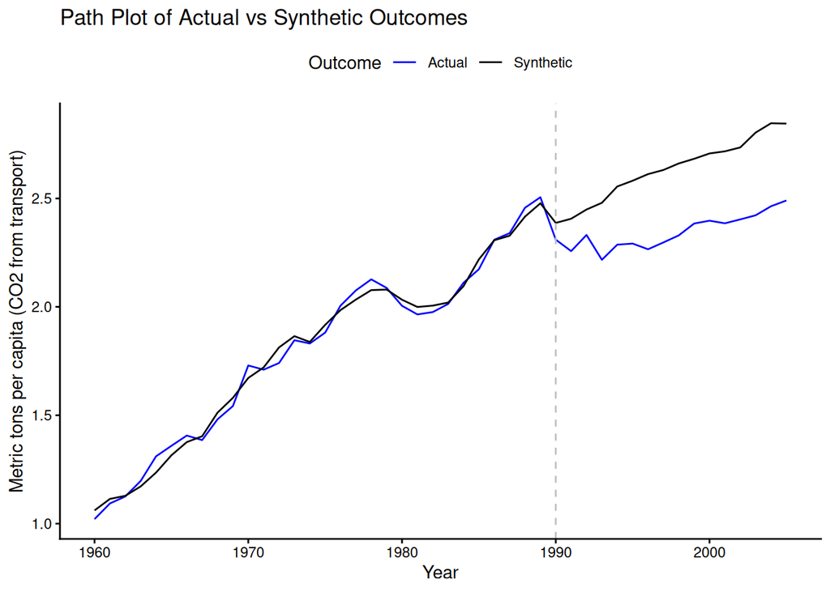

```r
# plot output
data_plot2 <-  data.table(year = 1960:2005,
                          co2_actual = Y1plot,
                          co2_synth = Y0plot %*% solution.w,
                          effects = Y1plot - (Y0plot %*% solution.w))

names(data_plot2) <-  c("year", "co2_actual", "co2_synth", "effects")

data_plot2 %>%
  ggplot(aes(x = year)) +
  geom_line(aes(y = co2_actual, color = "Actual")) +
  geom_line(aes(y = co2_synth, color = "Synthetic")) +
  labs(title = "Path Plot of Actual vs Synthetic Outcomes",
       x = "Year",
       y = "Metric tons per capita (CO2 from transport)") +
  scale_color_manual(name = "Outcome", values = c("Actual" = "blue", "Synthetic" = "black")) +
  theme_classic()+
  theme(legend.position = "top")+
  geom_vline(xintercept = 1990, linetype = 'dashed', color = "grey")
```

Okay great, we’ve recreated the main analysis we saw from the application above!

Now that we’ve explored what’s going on under the hood, I am thankful you can just call `Synth()` instead of having to code this up every time. I hope you are too!

Big thanks to the author(s) for writing up this amazing package :) and I hope this was a helpful little primer.

For more I really recommend this explanation for a general and practical intro *(plus it’s in python which is cool)*: https://matheusfacure.github.io/python-causality-handbook/15-Synthetic-Control.html.

I also recommend this paper that explores the practical applications of synthetic control in a more academic style: https://par.nsf.gov/servlets/purl/10331930.